# R Basics

Yanchao Liu

2019

## Basic Commands

R uses functions to perform operations. To call a function, we type the function name followed by a pair of parentheses enclosing the needed arguments.

### Create a vector and do some calculations

Create a vector of numeric values and assign it to variable x:

```r
x <- c(1, 3, 2, 5)
x
```

```
[1] 1 3 2 5
```

To echo back (display) the result of an assignment, we can enclose the statement in parentheses, like this:

```r
(x <- c(1, 3, 2, 5))
```

```
[1] 1 3 2 5
```

Add 100 to every element in x and assign the result to y,

```r
(y <- 100 + x)
```

```
[1] 101 103 102 105
```

Add x and y and assign the result to x, since x and y are vectors of the same length, the addition is element-wise, i.e., add each element of y to the corresponding element of x:

```r
(x <- x + y)
```

```
[1] 102 106 104 110
```

We can perform a calculation and display the result to the screen, without assigning it to any variable. For example, calculate the x divided by $\pi$,

```r
x/pi
```

```
[1] 32.46761 33.74085 33.10423 35.01409
```

### Concatenate vectors

Concatenate x and y and assign the result to xy:

```r
(xy <- c(x,y))
```

```
[1] 102 106 104 110 101 103 102 105
```

Display the length of xy:

```r
length(xy)
```

```
[1] 8
```

Pre-append three 5’s and post-append the sequence from 1 to 5 to xy:

```r
c(rep(5,3), xy, seq(5))
```

```
 [1]   5   5   5 102 106 104 110 101 103 102 105   1   2   3   4   5
```

To learn the usage of a function, type ? followed by the function name (no space between ? and the function name):

```r
?rep
```

### Access elements of a vector

The first element of xy:

```r
xy[1]
```

```
[1] 102
```

The 2nd to the 5th elements of xy:

```r
xy[2:5]
```

```
[1] 106 104 110 101
```

The 2nd to the last elements of xy:

```r
xy[2:length(xy)]
```

```
[1] 106 104 110 101 103 102 105
```

Odd elements of xy:

```r
xy[which(xy %% 2 == 1)]
```

```
[1] 101 103 105
```

### Create a matrix and do some calculations

Create a matrix from x:

```r
(A <- matrix(x, nrow = 2))
```

```
     [,1] [,2]
[1,]  102  104
[2,]  106  110
```

Square root of the matrix A:

```r
sqrt(A)
```

```
         [,1]     [,2]
[1,] 10.09950 10.19804
[2,] 10.29563 10.48809
```

Add some random noise to A, and assign the result to B:

```r
(B <- A + rnorm(4, mean=0, sd = 1))
```

```
         [,1]     [,2]
[1,] 102.4714 103.8476
[2,] 106.8980 108.1845
```

Transpose of A:

```r
t(A)
```

```
     [,1] [,2]
[1,]  102  106
[2,]  104  110
```

### Matrix multiplication

Create two matrices and a vector:

```r
(A <- matrix(seq(4), nrow = 2))
```

```
     [,1] [,2]
[1,]    1    3
[2,]    2    4
```

```r
(B <- matrix(c(4,3,8,1), nrow = 2))
```

```
     [,1] [,2]
[1,]    4    8
[2,]    3    1
```

```r
(x <- c(1.5, 2))
```

```
[1] 1.5 2.0
```

Element-wise multiplication:

```r
A*B
```

```
     [,1] [,2]
[1,]    4   24
[2,]    6    4
```

Matrix multiplication:

```r
A %*% B
```

```
     [,1] [,2]
[1,]   13   11
[2,]   20   20
```

Matrix-vector multiplication:

```r
A %*% x
```

```
     [,1]
[1,]  7.5
[2,] 11.0
```

Matrix inverse:

```r
solve(A)
```

```
     [,1] [,2]
[1,]   -2  1.5
[2,]    1 -0.5
```

Suppose ( Ay = x), we know $A$ and $x$, then $y = A^{-1} x$:

```r
(y <- solve(A) %*% x)
```

```
     [,1]
[1,]  0.0
[2,]  0.5
```

Get the dimension of a matrix:

```r
dim(A)
```

```
[1] 2 2
```

### Access elements of a matrix

Create a 4-by-4 matrix:

```r
(A <- matrix(1:16, 4, 4))
```

```
     [,1] [,2] [,3] [,4]
[1,]    1    5    9   13
[2,]    2    6   10   14
[3,]    3    7   11   15
[4,]    4    8   12   16
```

Select the element $A_{2,3}$:

```r
A[2,3]
```

```
[1] 10
```

Select the 3rd row of A:

```r
A[3,]
```

```
[1]  3  7 11 15
```

Select the 1st column of A:

```r
A[,1]
```

```
[1] 1 2 3 4
```

Select the 1st and 3rd columns of A:

```r
A[,c(1,3)]
```

```
     [,1] [,2]
[1,]    1    9
[2,]    2   10
[3,]    3   11
[4,]    4   12
```

Select all but the 2nd and 4th row of A:

```r
A[-c(2,4),]
```

```
     [,1] [,2] [,3] [,4]
[1,]    1    5    9   13
[2,]    3    7   11   15
```

Note that when we generate a matrix from a vector, the default arrangement of elements in the matrix is *by column*, to make a *by row* arrangement:

```r
matrix(1:16, 4,4, byrow = T)
```

```
     [,1] [,2] [,3] [,4]
[1,]    1    2    3    4
[2,]    5    6    7    8
[3,]    9   10   11   12
[4,]   13   14   15   16
```

### Generate random numbers

To make our code to reproduce the exact same set of random numbers each time we run it, we can use the `set.seed()` function:

```r
set.seed(2018)
```

Generate two vectors of *standard normal* random numbers:

```r
x <- rnorm(100)
y <- rnorm(100)
```

Get the mean, variance and standard deviation of $x$, and the covariance and correlation between $x$ and $y$:

```r
c(mean(x), var(x), sd(x), cov(x,y), cor(x,y))
```

```
[1]  0.021191943  1.027290677  1.013553490 -0.006601261 -0.006396354
```

Plot the distribution of $x$ and produce the scatterplot of $y$ against $x$:

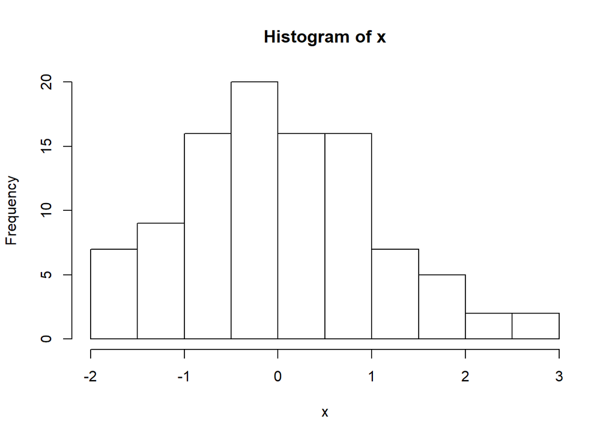

```r
hist(x)
```

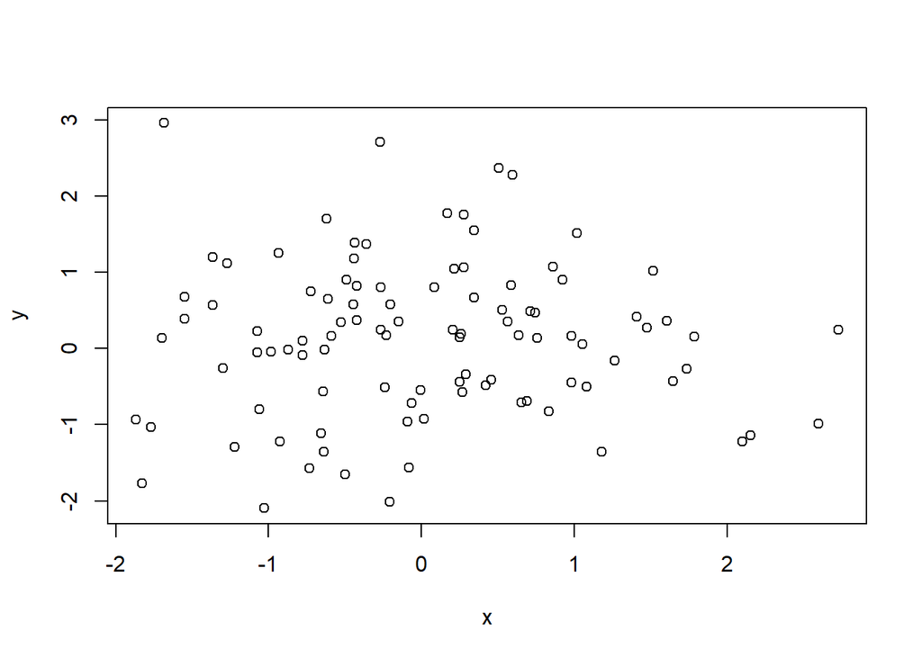

```r
plot(x,y)
```

### Work with a data frame

A data frame is like a table of data, each row is a record (observation, example, data point) and each column is a variable (attribute, feature, field). We rarely need to manually create a data frame in R, as most of the time the data is loaded from some data file. For the purpose of illustration, let’s create a small data frame:

```r
df <- data.frame(ID = c('aa0001','ab0001','gk0399','ss1234','kn0022'),
                       age = c(25, 51, 29, 40, 33),
                       test_score = c(89, 92, 77, 85, 90)
                       )
```

Display the first few (by default 6) rows of the data frame:

```r
head(df)
```

```
      ID age test_score
1 aa0001  25         89
2 ab0001  51         92
3 gk0399  29         77
4 ss1234  40         85
5 kn0022  33         90
```

Display the dimenstion, a summary and the structure of the data frame:

```r
dim(df)
```

```
[1] 5 3
```

```r
summary(df)
```

```
      ID         age         test_score
 aa0001:1   Min.   :25.0   Min.   :77.0
 ab0001:1   1st Qu.:29.0   1st Qu.:85.0
 gk0399:1   Median :33.0   Median :89.0
 kn0022:1   Mean   :35.6   Mean   :86.6
 ss1234:1   3rd Qu.:40.0   3rd Qu.:90.0
            Max.   :51.0   Max.   :92.0
```

```r
str(df)
```

```
'data.frame':   5 obs. of  3 variables:
 $ ID        : Factor w/ 5 levels "aa0001","ab0001",..: 1 2 3 5 4
 $ age       : num  25 51 29 40 33
 $ test_score: num  89 92 77 85 90
```

Access a particular column of a data frame:

```r
df$age
```

```
[1] 25 51 29 40 33
```

```r
df[,'age']
```

```
[1] 25 51 29 40 33
```

Access a subset of columns of a data frame:

```r
df[, c('ID','test_score')]
```

```
      ID test_score
1 aa0001         89
2 ab0001         92
3 gk0399         77
4 ss1234         85
5 kn0022         90
```

Select certain rows of a data frame:

```r
df[1:3, ]
```

```
      ID age test_score
1 aa0001  25         89
2 ab0001  51         92
3 gk0399  29         77
```

```r
df[which(df$age >= median(df$age)), ]
```

```
      ID age test_score
2 ab0001  51         92
4 ss1234  40         85
5 kn0022  33         90
```

Generate a scatterplot for two columns of the data frame:

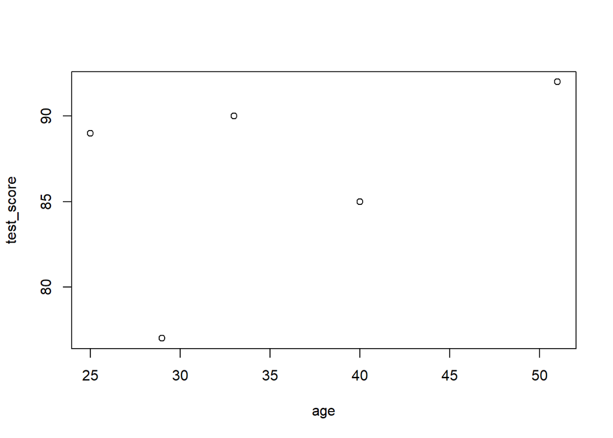

```r
plot(df[, c('age','test_score')])
```

Get the column names and row names of the data frame:

```r
colnames(df)
```

```
[1] "ID"         "age"        "test_score"
```

```r
rownames(df)
```

```
[1] "1" "2" "3" "4" "5"
```

Let’s set the ID column as the row names and delete the ID column:

```r
rownames(df) <- df$ID
df$ID <- NULL
df
```

```
       age test_score
aa0001  25         89
ab0001  51         92
gk0399  29         77
ss1234  40         85
kn0022  33         90
```

We can also change the column names, for example:

```r
(colnames(df) <- c('Age','Score'))
```

```
[1] "Age"   "Score"
```

```r
df
```

```
       Age Score
aa0001  25    89
ab0001  51    92
gk0399  29    77
ss1234  40    85
kn0022  33    90
```

Create a data frame (name it *df1*) consisting of two columns, column x is uniformly distributed between -2 and 2, and y is a linear function of x plus some noise:

```r
df1 <- data.frame(x = runif(100, -2, 2))
df1$y <- 2 + 3*df1$x + rnorm(100, sd=5)
head(df1)
```

```
           x         y
1  0.9246528 12.711969
2  1.2558163 11.000255
3 -1.7908489  2.658702
4  1.1611826  1.010752
5  1.5919711 10.978948
6 -0.8926442  4.909903
```

Plot the points (x, y) and the line y = 2 + 3x:

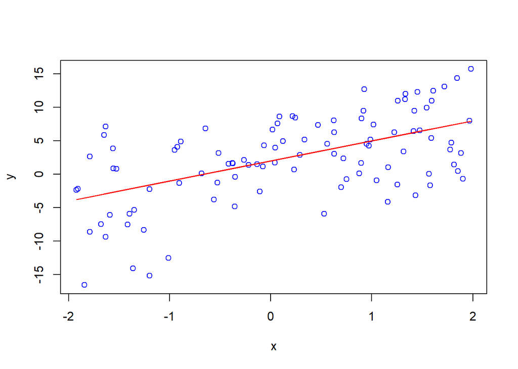

```r
plot(df1[,c('x','y')], col = 'blue')
lines(df1$x, 2 + 3*df1$x, type = 'l', col = 'red')
```

### Save R objects to a data file

We can use the `save` function to save things in a data file. Let’s save the matrix $A$, the data frame *df* and *df1* to a file called *lab1.RData*.

```r
save(file = 'lab1.RData', A, df, df1)
```

Next time we open R and come to the same work director (via `setwd`), we can load the saved data from file by

```r
load('lab1.RData')
```

## Exercises

### Exercise 1

Manually input the data table of ISLR 2.4 Exercise 7 into a data frame called *ex7*. The data frame should contain 6 rows and 4 columns. Then save it to a data file called *ex7.RData* under your work directory.

### Exercise 2

Use R to solve the following system of linear equations:

$4 x + 2 y + 7 z = 5$

$4 x + 5 y + 2 z = 2.5$

$7 x + 8 y + 9 z = 7$

and print out the solution.

### Exercise 3

Generate a vector (name it whatever you like, e.g., $a$) of length 100, with each element being a random number uniformly distributed between $1$ and $5$. Generate another vector, e.g., $b$, which is equal to $log(a)$ plus a random noise of mean 0 and standard deviation 0.5. Plot out the scatterplot of $a$ v.s. $b$, and save the plot to a pdf file, e.g., *a.pdf*. (Note: you can save a plot to PDF by sandwich the `plot` command between commands `pdf("a.pdf")` and `dev.off()`.)